# Who Americans spend time with

Marlies Smit

2026-02-17

### Research Question

#### Do Americans who spent more time with a partner spend less time alone?

Did Americans who said they spent more time with partners also say that they spent less time alone, and were there any contributing factors to how much time people spent alone based on the data collected?

```r
csv = read.csv("Data/time-spent-with-relationships-by-age-us.csv")
# head(csv, n = 10)

df <- csv %>% select(-With.children, -With.family, -With.coworkers) %>%
  rename("Sex" = "Entity") %>%
  rename("Age" = "Year")
# head(df, n = 10)
```

### Data set introduction

```r
variables <- data.frame(
  Name = c("Sex",
           "Age",
           "Alone",
           "With friends",
           "With partner"),
  Description = c("Divided in categories: All people, Men and Women",
                  "Ages between ages 15 to 80",
                  "Time in hours per day reported alone",
                  "Time in hours per day reported with friends",
                  "Time in hours per day reported with partner"
                  )
)

kable(variables, col.names = c(
  "Name",
  "Description"),
  format = "pipe", padding = 15,
  caption = "Data set variables with a brief description"
  )
```

Data set variables with a brief description

| Name | Description |
| --- | --- |
| Sex | Divided in categories: All people, Men and Women |
| Age | Ages between ages 15 to 80 |
| Alone | Time in hours per day reported alone |
| With friends | Time in hours per day reported with friends |
| With partner | Time in hours per day reported with partner |

### Data set description

```r
# number of observations
num_row = nrow(df)
# num_row

# checking  variable types

var_type = sapply(df, class)
# var_type
```

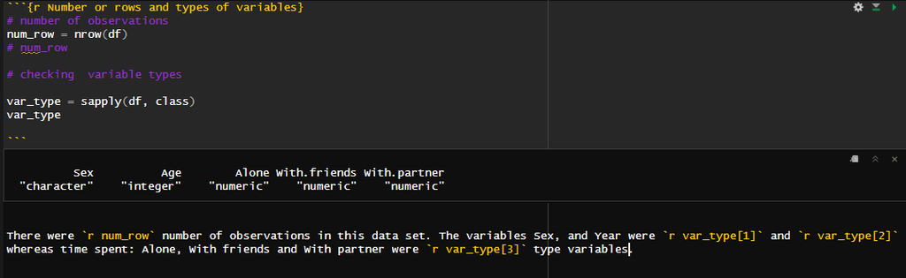

```r
knitr::include_graphics("Image/rows_and_vars_image.png")
```

Below shows a dataframe with the first two rows of the data set, as well as the variable names and types.

```r
string = str(head(df,2))
```

```
## 'data.frame':    2 obs. of  5 variables:
##  $ Sex         : chr  "All people" "All people"
##  $ Age         : int  15 16
##  $ Alone       : num  3.63 3.87
##  $ With.friends: num  1.58 1.53
##  $ With.partner: num  0 0.00173
```

### Data summary

```r
Summaries <- df %>%
  group_by(Sex) %>%
  summarize(Mean_alone = mean(Alone),
            Mean_with.partner = mean(With.partner),
            Sum_alone = sum(Alone),
            Sum_with.patner = sum(With.partner))
```

```r
kable(Summaries, col.names = c(
  "Sex",
  "Mean alone",
  "Mean with partner",
  "Sum alone",
  "Sum with partner"),
  format = "pipe", padding = 15,
  caption = "Mean and sum of time spent with partner and time spent alone for men and women"
  )
```

Mean and sum of time spent with partner and time spent alone for men and women

| Sex | Mean alone | Mean with partner | Sum alone | Sum with partner |
| --- | --- | --- | --- | --- |
| All people | 6.050151 | 3.044196 | 399.3099 | 200.9170 |
| Men | 6.303640 | 3.281346 | 416.0402 | 216.5689 |
| Women | 5.788442 | 2.847829 | 382.0372 | 187.9567 |

The table showed that men on average reported more time with their partner and more time alone compared to women. Both men and women spent on average almost **double** the amount of time by themselves than with a partner.

### Visulisations

```r
visual_df <- subset(df, Sex != "All people")

Time_distro <- ggplot(visual_df, aes(x = Alone,
                      y= With.partner,
                      fill = Sex,
                      label = Age)) +
  geom_point(size = 3, alpha = 0.5, shape=21, color= "black")+
  labs(y = "Time spent with partner", x = "Time spent alone", fill = "Sex", title = "Time spent alone by time spent with partner") +
  scale_fill_manual(values = colors) +
  scale_size(range = c(1, 20), name = " ")+
  # adjusting the increments on both axes
  scale_x_continuous(breaks = seq(0, 9, by = 1)) +
  scale_y_continuous(breaks = seq(0, 9, by = 1)) +
  coord_cartesian(xlim = c(3, 9), ylim = c(0, 6)) +
  theme_light()

ggplotly(Time_distro, tooltip = c("Sex", "Age"))
```

[interactive chart not shown]

- *Women on average did not tend to spend more than four hours with a partner regardless of how much or little time they spend alone.*
- *Men who reported spending the most time alone, also reported spending the most time with a partner, overlaying age data, we can see that it was men between ages 65 and 80 who were represented. Hover over each point on the graph to show gender and age information.*

### Further analysis

We identified age as a possible factor in how much time people spend alone. We conducted further analysis by looking at age as a factor. First we looked at averages of the data grouped by age brackets of ten years and included average for time spent with friends. Then we used a line graph to show a higher level of granularity, showing at which age shifts occur in with who people their time.

```r
# used gemini response of how to group by age
ten_year_df <- df %>%
  mutate(Age_group = case_when(
    Age <= 24 ~ "15-24",
    Age <= 34 ~ "25-34",
    Age <= 44 ~ "35-44",
    Age <= 54 ~ "45-54",
    Age <= 64 ~ "55-64",
    Age > 64 ~ "65-80",
  )) %>%
  group_by(Age_group, Sex) %>%
  summarise(
    Alone_mean = mean(Alone),
    With.partner_mean = mean(With.partner),
    With.friends_mean = mean(With.friends)
  )

ten_year_df <- subset(ten_year_df, Sex == "All people")
ten_year_df <- subset(ten_year_df, select = -Sex)

kable(ten_year_df, col.names = c(
  "Age group",
  "Alone mean",
  "With partner mean",
  "With friends mean"),
  format = "pipe", padding = 15,
  caption = "Mean of time spent by age group"
  )
```

Mean of time spent by age group

| Age group | Alone mean | With partner mean | With friends mean |
| --- | --- | --- | --- |
| 15-24 | 4.587589 | 0.5443963 | 1.7031625 |
| 25-34 | 4.754158 | 2.8985648 | 0.8862235 |
| 35-44 | 5.058138 | 3.3190951 | 0.5810632 |
| 45-54 | 6.141209 | 3.0871984 | 0.5173562 |
| 55-64 | 7.070821 | 3.3924218 | 0.5068068 |
| 65-80 | 7.699425 | 4.2812616 | 0.5745682 |

The results of the table showed as indicated by the scatterplot that the younger age groups spent on average less time alone. 15 to 24 year olds spent the least time alone, whereas people over 65 spent the most time alone, averaging an extra three hours a day. Time with friends plateaued after age 35 and remained averaging around half an hour a day (between 0.6 and 0.5).

This line graph showed the relationship between age and how people spent their time. The line graph showed that people spent more time alone or with a partner as they got older and that time spent with friends decreased from about age 18 and plateaued around age 37.

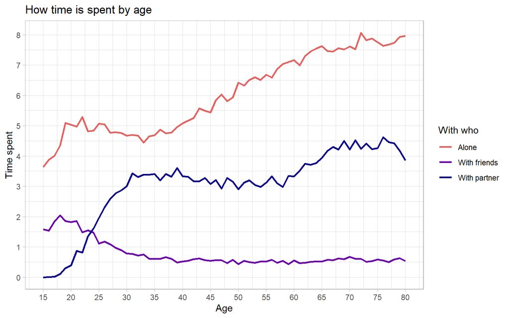

```r
visual_df2 <- df %>%
  pivot_longer(
  cols = c("Alone", "With.partner", "With.friends"),
  names_to = "With_who",
  values_to =  "Time_spent"
  )

visual_df2 <- subset(visual_df2, Sex == "All people")




Line_graph <- ggplot(visual_df2, aes(
  x = Age,
  y = Time_spent,
  group = With_who,
  color = With_who)) +
  geom_line(linewidth = 1) +
  scale_x_continuous(breaks = seq(15, 80, by = 5)) +
  scale_y_continuous(breaks = seq(0, 9, by = 1)) +
  theme_light() +
  labs(y = "Time spent", x = "Age", color = "With who", title = "How time is spent by age") +
  scale_color_manual(values = colors,
                     labels = c("Alone" = "Alone",
                                "With.friends" = "With friends",
                                "With.partner" = "With partner"))

Line_graph
```

### Conclusions

Do Americans who spent more time with a partner spend less time alone? The data indicated that time spent with a partner did not detract from time being alone. However with further analysis we could see that their was an inverse relationship between time spent with friends and time spent with partner. Whereas time spent alone steadily increased from age 35.

From the mean and summary table we could see that men on average spent more time by themselves and with a partner compared to women.We further explored the relationship of how much time people spent alone compared to how much time they spent with their partner by creating a scatterplot. The scatterplot showed that there was no inverse relationship and that time spent with a partner remained consistent for women even as they spent more time alone.

The “Mean of time spent by age group” table and line graph indicated that age had a more significant relationship on how much time respondents spent alone.